# UPlayBall 특성훈련 시스템 구현 기획

# UPlayBall 특성훈련 시스템 구현 기획

문서 버전: 1.0  
목표: 프야매 특성훈련의 카드 육성 감각을 유지하되, 싱글게임에 맞춰 실패·파괴·과도한 반복 없이 선수를 원하는 방향으로 성장시킨다.

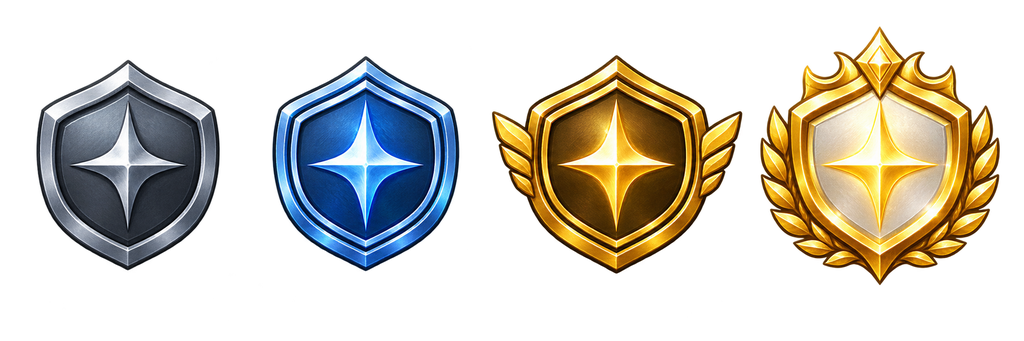

특성훈련 등급 아이콘 시안

## 1. 핵심 결정

| 항목 | 결정안 |
| --- | --- |
| 해금 시점 | 첫 시즌 종료 후 첫 오프시즌 진입 시 해금 |
| 이용 가능 기간 | 오프시즌 전용 |
| 선수당 특성 | 1개 장착, 언제든 다른 특성으로 교체 가능 |
| 등급 | C → B → A → S, 4단계 |
| 실패 | 없음. 요구 경험치를 채우면 100% 승급 |
| 재료 소멸 | 기본안은 `훈련 파트너 지정` 후 오프시즌 훈련 횟수 소비. 선수카드는 소멸하지 않음 |
| 랜덤성 | 신규 특성 최초 획득 시 3개 후보 중 1개 선택. 재추첨 1회 무료 |
| 비용 | 구단 자금 + 특성 훈련 포인트(TP) |
| 카드 표시 | 카드 우측 상단에 등급 아이콘만 노출. 특성명은 상세/툴팁에서 표시 |
| 중복 효과 | 동일 특성 중첩 가능. 단, 선수 개인에게는 하나만 장착 |

## 2. 메뉴 경로

### 주 경로

`메인 로비 → 선수단 → 선수 성장 → 특성훈련`

선수 성장 화면의 탭 순서는 다음으로 고정한다.

`주간 훈련 | 해외 훈련 | 훈련 파트너 | 성장 블록 | 특성훈련`

- 정규시즌: 특성훈련 탭은 잠금 표시. 진입 시 “특성훈련은 오프시즌에 진행할 수 있습니다.” 안내와 `일정 보기` 버튼 제공.
- 오프시즌: 탭 활성화.
- 카드 상세 보조 경로: `선수카드 상세 → 성장 → 특성`의 `훈련하러 가기` 버튼. 대상 선수를 선택한 상태로 특성훈련 화면 진입.
- 첫 해금 시 매니저 안내 1회 출력: 대상 선택 → 파트너 선택 → 결과 선택 → 카드 아이콘 확인의 4단계.

## 3. 화면 구성

### 프야매 화면 레퍼런스

훈련 메인

소멸 경고

[figure not shown]

[figure not shown]

결과 선택

카드 배지

[figure not shown]

[figure not shown]

### 3.1 특성훈련 메인 화면

| 영역 | 구성 | 동작 |
| --- | --- | --- |
| 상단 | 메뉴명, 보유 TP, 구단 자금, 도움말 | 재화 확인 및 규칙 열람 |
| 좌측 38% | 훈련 대상 선수카드, 현재 특성, 등급, 경험치 게이지 | `선수 변경`으로 대상 선택 |
| 우측 상단 | 훈련 파트너 카드 목록 | 포지션·등급·팀·이름 필터 및 정렬 |
| 우측 중단 | 선택 파트너 슬롯 1~3개, 획득 예상 경험치 | 카드 선택 즉시 결과 미리보기 |
| 우측 하단 | 비용, 승급 결과, 훈련 버튼 | 조건 만족 시 활성화 |
| 하단 안내 | 파트너는 사라지지 않으며 훈련 횟수만 소모됨을 명시 | 불안 요소 제거 |

### 3.2 대상 선수 선택 팝업

- 카드 그리드: 5열, 스크롤.
- 필터: 타자/투수, 포지션, 주전/후보, 특성 보유 여부, 특성 등급.
- 정렬: 종합 능력치, 카드 등급, 이름, 현재 특성 등급.
- 제외: 은퇴, 부상 치료 중, 해외 훈련 중인 선수.
- 카드에는 현재 특성 등급 아이콘만 표시하고 미보유 선수는 빈 슬롯 또는 `+` 표시.

### 3.3 결과 화면

훈련 버튼 선택 후 즉시 결과를 적용하고 다음을 보여준다.

1. 경험치 게이지 증가 애니메이션 0.5초.
2. 승급 시 기존 아이콘 → 신규 아이콘 전환.
3. 특성 최초 획득 시 후보 3개 제시.
4. 선택 전에는 저장되지 않으며, `결정` 후 확정.
5. `다시 훈련`과 `카드 확인` 제공.

스킵 옵션 활성화 시 애니메이션을 생략하고 결과만 표시한다.

## 4. 기본 플레이 규칙

### 4.1 최초 특성 획득

- 특성이 없는 선수가 C등급 요구치를 채우면 해당 선수의 포지션군에 맞는 후보 3개를 제시한다.
- 사용자가 직접 하나를 선택한다.
- 후보가 마음에 들지 않으면 1회 무료 재추첨한다.
- 두 번째 재추첨부터 소량의 TP를 사용한다. 비용은 고정하여 재추첨 연속 증가 스트레스를 만들지 않는다.
- 수비 위치와 맞지 않거나 발동 불가능한 특성은 후보에서 제외한다.

### 4.2 등급 성장

| 단계 | 누적 TP 경험치 | 파트너 슬롯 | 효과 배율 | 목표 체감 |
| --- | --- | --- | --- | --- |
| 미보유 → C | 100 | 1 | 100% | 오프시즌 1회면 획득 가능 |
| C → B | 250 | 1 | 125% | 주전 육성의 기본 단계 |
| B → A | 500 | 2 | 155% | 핵심 선수 투자 단계 |
| A → S | 900 | 3 | 190% | 1~2시즌 장기 목표 |

위 수치는 밸런스 초안이며, 플레이테스트에서는 한 오프시즌에 일반 주전 2~3명이 C 또는 B를 달성하고 핵심 선수 1명이 A 이상을 노릴 수 있는 속도를 목표로 한다.

### 4.3 훈련 파트너 경험치

| 파트너 조건 | 기본 경험치 | 추가 보너스 |
| --- | --- | --- |
| 후보/육성 선수 | 40 | 없음 |
| 주전급 선수 | 60 | 없음 |
| 동일 포지션군 | 기본값 | +20% |
| 동일 팀 또는 훈련 궁합 | 기본값 | +10% |
| 해당 시즌 우수 성적 | 기본값 | +10% |

- 한 선수는 오프시즌에 기본 2회의 파트너 훈련을 제공한다.
- 파트너는 소멸하지 않는다.
- 같은 조합을 반복해도 실패하지 않는다.
- 이미 획득한 경험치는 특성 변경 후에도 등급 경험치로 보존한다.

### 4.4 비용

`훈련 비용 = 기본 비용 × 목표 등급 계수 × 선택 파트너 수`

| 목표 등급 | 계수 |
| --- | --- |
| C | 1.0 |
| B | 1.5 |
| A | 2.2 |
| S | 3.2 |

구단 자금은 반복 플레이로 확보하고 TP는 경기·시즌 목표·오프시즌 보상으로 지급한다. 현금성 재화나 확률 상승 아이템은 두지 않는다.

## 5. 특성 구성 초안

### 타자

| 특성 | 효과 예시 | 후보 조건 |
| --- | --- | --- |
| 타격의 정석 | 교타 보정 | 모든 타자 |
| 해결사 | 득점권 타격 보정 | 중심타선 적성 |
| 선두 출루 | 주자 없을 때 출루 보정 | 상위타선 적성 |
| 장타 본능 | 장타 발생 보정 | 장타 기준 충족 |
| 작전 수행 | 번트·진루타 성공 보정 | 번트 기준 충족 |
| 철벽 수비 | 수비 실책 억제 | 수비 기준 충족 |
| 도루 감각 | 도루 성공 및 주루 보정 | 주력 기준 충족 |

### 투수

| 특성 | 효과 예시 | 후보 조건 |
| --- | --- | --- |
| 에이스 본능 | 선발 등판 초반 안정성 | 선발 적성 |
| 위기관리 | 득점권 피안타 억제 | 모든 투수 |
| 탈삼진 본능 | 2스트라이크 이후 탈삼진 보정 | 구위 기준 충족 |
| 땅볼 유도 | 장타 억제·땅볼 유도 | 변화구 기준 충족 |
| 이닝이터 | 투구 수 증가 시 체력 감소 완화 | 선발 적성 |
| 셋업맨 | 7~8회 등판 보정 | 계투 적성 |
| 끝판왕 | 9회 리드 상황 보정 | 마무리 적성 |

효과는 스탯 숫자를 무조건 올리는 방식보다 경기 상황에 반응하는 조건부 보정으로 설계한다. 카드 상세에는 발동 조건과 현재 등급 수치를 명확히 표시한다.

## 6. 카드 UI 표시

### 6.1 기본 규격

- 위치: 선수카드 우측 상단. 카드 등급·연도·잠금 표시와 겹치면 우측 중앙 상단으로 이동.
- 카드 원본 대비 크기: 카드 짧은 변의 13%.
- 최소 화면 크기: 24×24px, 권장 32×32px, 상세 카드 48×48px.
- 표시는 등급 아이콘 하나만 사용. 카드 앞면에는 특성명, C/B/A/S 문자, 수치 미표시.
- 마우스 오버/포커스: `특성명 · 등급 · 핵심 효과` 툴팁.
- 미보유: 경기·선수 목록 카드에는 아무것도 표시하지 않음. 성장 화면에서만 빈 슬롯 표시.

### 6.2 등급별 시각 언어

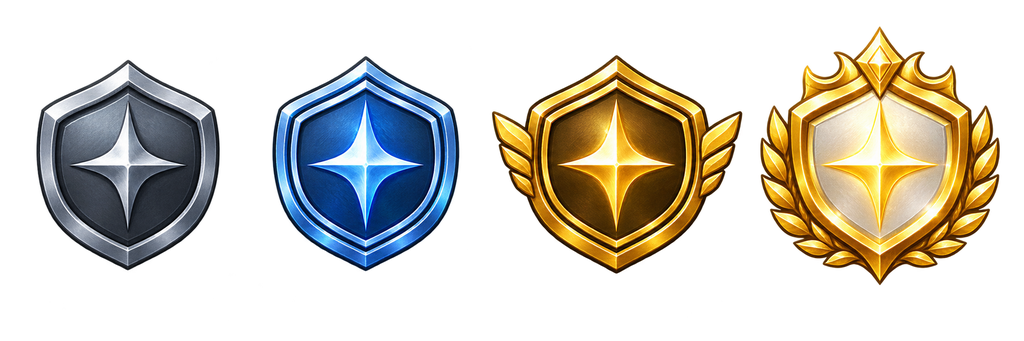

C B A S 등급별 특성 아이콘

| 등급 | 색 | 외곽 형태 | FX |
| --- | --- | --- | --- |
| C | 은회색 | 단일 방패 테두리 | 없음 |
| B | 청색 | 이중 테두리 | 약한 내부 광택 |
| A | 금색 | 측면 날개 장식 | 짧은 금빛 글린트 |
| S | 금백색 | 월계관·상단 장식 | 절제된 호흡광 |

- 모든 등급은 동일한 중심 심볼을 유지해 ’특성 아이콘’임을 즉시 인지시킨다.
- 색각 이상 대응을 위해 색뿐 아니라 테두리 수와 장식 실루엣으로도 구분한다.
- 카드가 여러 효과로 복잡해지는 것을 막기 위해 상시 파티클은 S등급에만 허용한다.
- 선택/호버 시 아이콘을 1.08배 확대하며 0.12초 ease-out을 적용한다.

### 6.3 ImageGen 산출물 처리

- 생성 시안: C/B/A/S가 좌→우로 배치된 투명 배경 4종 아이콘 시트.
- 실제 적용 전 개별 PNG로 분리하고 동일 캔버스·피벗을 맞춘다.
- 권장 원본: 등급별 256×256 PNG, RGBA.
- Unity Import: Sprite (2D and UI), Alpha Is Transparency, Mesh Type Full Rect, Filter Mode Bilinear, Compression None(PC UI), Generate Mip Maps Off.
- 파일명: `TraitRank_C.png`, `TraitRank_B.png`, `TraitRank_A.png`, `TraitRank_S.png`.

## 7. UX 상태 및 문구

| 상태 | CTA/문구 |
| --- | --- |
| 대상 미선택 | `훈련할 선수를 선택하세요.` |
| 파트너 미선택 | `훈련 파트너를 선택하세요.` |
| 정규시즌 | `특성훈련은 오프시즌에 진행할 수 있습니다.` |
| TP 부족 | `특성 훈련 포인트가 부족합니다.` |
| 최대 등급 | `이 선수의 특성은 최고 등급입니다.` |
| 진행 확인 | `선택한 파트너의 훈련 횟수를 사용합니다. 선수는 사라지지 않습니다.` |
| 승급 | `특성이 {등급}등급으로 성장했습니다.` |
| 신규 획득 | `선수에게 부여할 특성을 선택하세요.` |

확인 팝업은 최초 1회만 기본 노출하고 이후 `다시 표시하지 않기`를 제공한다. 선수 소멸이 없으므로 프야매 원본의 강한 경고 팝업은 사용하지 않는다.

## 8. 데이터 설계

```csharp
public enum TraitRank { None, C, B, A, S }

[Serializable]
public sealed class PlayerTraitProgress
{
    public string traitId;
    public TraitRank rank;
    public int experience;
    public int freeRerollSeasonId;
}

[CreateAssetMenu(menuName = "UPlayBall/Trait Definition")]
public sealed class TraitDefinitionSO : ScriptableObject
{
    public string id;
    public string displayName;
    [TextArea] public string description;
    public PlayerRoleMask allowedRoles;
    public TraitEffectDefinition[] effectsByRank;
    public Sprite[] rankIcons; // C, B, A, S 공용 아이콘 참조 가능
}
```

권장 분리:

- `TraitDefinitionSO`: 정적 특성 정의와 등급별 효과.
- `PlayerTraitProgress`: 선수별 저장 데이터.
- `TraitTrainingConfigSO`: 등급 요구 경험치, 비용, 파트너 보너스.
- `TraitTrainingService`: 가능 여부·비용·후보 생성·결과 적용.
- `TraitEffectResolver`: 경기 시뮬레이션 중 발동 조건 판정.
- `TraitRankIconCatalogSO`: 카드 UI용 공용 등급 아이콘.

후보 3개 생성은 세이브 데이터에 후보 ID와 시드까지 저장한다. 결과 화면에서 종료하거나 강제 종료해도 다시 진입했을 때 동일 후보를 보여줘 리세마라를 막는다.

## 9. 처리 흐름

1. 오프시즌 여부 확인.
2. 대상 선수 상태 확인.
3. 파트너 유효성 및 남은 훈련 횟수 확인.
4. 비용·예상 경험치 계산.
5. 확인 입력.
6. 비용과 파트너 훈련 횟수를 하나의 트랜잭션으로 차감.
7. 경험치 반영 및 등급 계산.
8. 신규 획득이면 후보 3개 생성·저장.
9. 선택 결과 확정.
10. 선수카드 UI 이벤트 발행: `PlayerTraitChanged(playerId)`.
11. 카드 목록·상세·라인업 UI가 등급 아이콘 갱신.
12. 자동 저장.

## 10. 예외 처리

- 대상 선수와 파트너가 동일하면 선택 불가.
- 해외 훈련·부상 치료·은퇴 처리 중인 선수는 대상/파트너 제외.
- 파트너가 다른 오프시즌 활동에 배정되면 중복 사용 불가.
- 훈련 도중 시즌이 전환되면 확정 버튼 입력 시점에 다시 검사.
- 최대 S등급 선수는 경험치를 추가 획득하지 않음.
- 특성 변경 시 등급은 유지하되 변경 비용을 부과. 첫 변경은 시즌당 1회 무료.
- 카드 UI 아이콘 로드 실패 시 등급색 단색 원형 플레이스홀더를 표시하고 로그 기록.
- 세이브 마이그레이션 시 기존 선수는 `None/0`으로 초기화하며 첫 오프시즌에 보상 TP 지급.

## 11. 구현 작업 분해

### 1차: 데이터와 규칙

- 특성 정의, 등급, 경험치, 비용 테이블 구현.
- 가능 여부 검사와 훈련 결과 계산 서비스 구현.
- 세이브/로드 및 마이그레이션 구현.
- 결정론적 후보 3개 생성 구현.

### 2차: 메뉴와 훈련 화면

- 선수 성장 탭에 특성훈련 추가.
- 시즌 잠금 상태와 일정 보기 연결.
- 대상/파트너 선택 그리드 및 필터 구현.
- 비용·예상 결과 미리보기 구현.
- 결과 선택 및 재추첨 구현.

### 3차: 카드와 경기 연동

- 모든 카드 프리팹에 `TraitRankBadgeView` 추가.
- 등급 아이콘 카탈로그와 비동기 로드 처리.
- 카드 상세 툴팁 구현.
- 경기 시뮬레이션의 특성 발동 훅 구현.
- 경기 결과에서 발동 특성 기록 표시.

### 4차: 연출과 밸런스

- 게이지, 승급, 아이콘 전환 연출.
- 매니저 튜토리얼 4단계.
- 오프시즌당 획득 속도 텔레메트리.
- 특성별 승률·기용률·선택률 검증.

## 12. 인수 조건

- 오프시즌에만 실제 훈련을 확정할 수 있다.
- 대상과 파트너를 고르면 비용과 획득 경험치가 즉시 표시된다.
- 훈련은 실패하지 않고 선수카드는 소멸하지 않는다.
- 최초 등급 달성 시 유효한 특성 후보 3개가 표시된다.
- 강제 종료 후 재진입해도 미확정 후보가 바뀌지 않는다.
- 특성 확정 또는 승급 직후 모든 선수카드 UI에 올바른 등급 아이콘이 표시된다.
- 24px 카드에서도 C/B/A/S를 색과 실루엣으로 구분할 수 있다.
- 카드 앞면에는 아이콘만 보이며 특성명은 툴팁/상세에만 표시된다.
- 최대 등급, 재화 부족, 동시 활동, 시즌 전환 예외가 안전하게 차단된다.
- 기존 세이브 데이터 로드에 실패하지 않는다.

## 13. 원본 프야매 대비 변경점

| 프야매 참고 요소 | UPlayBall 적용 |
| --- | --- |
| 다른 선수카드를 훈련 재료로 소모 | 파트너의 오프시즌 훈련 횟수만 소비 |
| 특성 결과의 불확실성 | 3개 후보 중 직접 선택, 무료 재추첨 1회 |
| 반복 재료 투입 | 한 오프시즌의 명확한 성장 목표로 제한 |
| 강한 소멸 경고 팝업 | 최초 안내 후 간결한 확인 문구 |
| 카드에 랭크 배지 표시 | 등급 아이콘만 우측 상단에 표시 |
| 온라인 장기 소모 구조 | 싱글 캠페인 1~2시즌 내 핵심 선수 S 도달 가능 |

이 구조는 프야매의 ’선수카드를 활용해 고유 특성을 부여한다’는 감각은 유지하면서도, 싱글게임에서 불필요한 파괴·실패·장시간 반복을 제거한다.